# DSO 522: In-Class Workbook 9

Matteo Sesia

October 22, 2024

# Instructions

Your task is to edit this R Markdown notebook to include your solutions, ensuring that it is well-organized and professional in appearance. Answers must be clear and concise. Start by downloading the Rmd file.

**Collaboration Policy.** You are allowed to discuss this workbook with your classmates and work in groups. Despite group discussions, each student must write and submit their own solutions.

**Assistance Policy.** You may ask for clarifications from the instructor and teaching assistant in class. Do not seek help on these workbooks outside of class, as they are intended to be completed during class time.

**Submission Requirements.** Solutions must be submitted on Brightspace as a PDF writeup. Use the ‘Knit to PDF’ feature in RStudio to prepare your PDF document. Ensure that your PDF document looks like the provided PDF version of the workbook, including all code used to obtain the results in proper code blocks. Make sure your PDF writeup includes *your name* in the title (replace my name with yours).

**Grading Criteria.** This workbook is worth 10 points. To achieve a grade of 10, your writeup must correctly answer all questions, be easy to understand, and be formatted correctly.

**Work Timeline.** You are expected to work on this assignment in class, but you may complete it at home within 24 hours. It is due on October 23, 2024, at 9:30 pm. Late submissions will incur a 50% deduction for any initial delay below 24 hours, and an additional 10% deduction for each additional day.

Remember, you will need to use the `fpp3` package to complete this assignment, as shown in the lecture.

```r
suppressMessages(library(fpp3))
```

**NOTE:** only Problem 1 needs to be completed in order to receive full credit for this assignment. Problem 2 is optional.

# Problem 1

A classic example of a non-stationary series are stock prices. Plot the daily closing prices for Amazon stock (contained in `gafa_stock`), along with the ACF and PACF. Explain how each plot shows that the series is non-stationary and should be differenced.

# Problem 1 Solutions

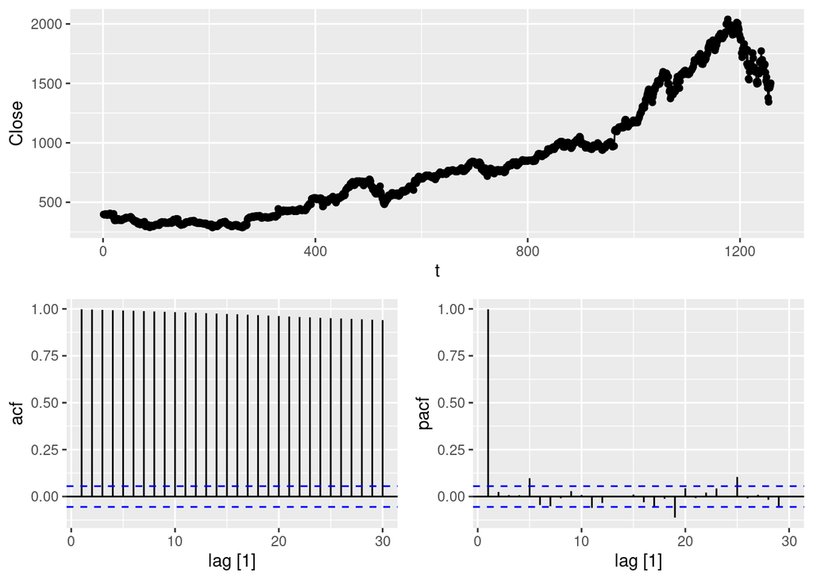

```r
gafa_stock |>
  filter(Symbol == "AMZN") |>
  mutate(t = row_number()) |>
  update_tsibble(index = t, regular=TRUE) |>
  gg_tsdisplay(Close, plot_type = "partial")
```

- The time plot shows the series “wandering around”, which is a typical indication of non-stationarity. Differencing the series should remove this feature.
- ACF does not drop quickly to zero, moreover the value $r_1$ is large and positive (almost 1 in this case). All these are signs of a non-stationary time series. Therefore it should be differenced to obtain a stationary series.
- PACF value $r_1$ is almost 1. All other values $r_i, i>1$ are small. This is a sign of a non-stationary process that should be differenced in order to obtain a stationary series.
- Overall, this suggests ARIMA(1,d,0), probably with d=1.

# Problem 2

For the following series, find an appropriate Box-Cox transformation and order of differencing in order to obtain stationary data. a. Turkish GDP from `global_economy`. b. Accommodation takings in the state of Tasmania from `aus_accommodation`. c. Monthly sales from `souvenirs`.

Then, for the souvenirs data, write down the differences you chose above using backshift operator notation.

# Problem 2 Solutions

1. Turkish GDP from `global_economy`.

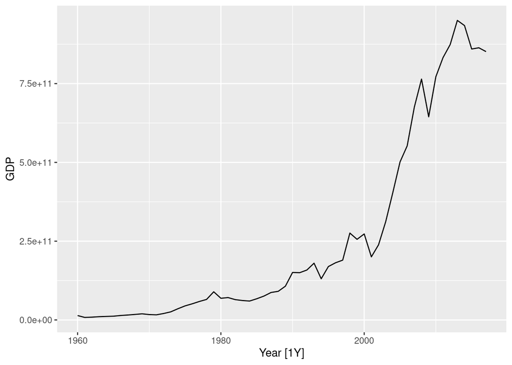

```r
turkey <- global_economy |> filter(Country == "Turkey")
turkey |> autoplot(GDP)
```

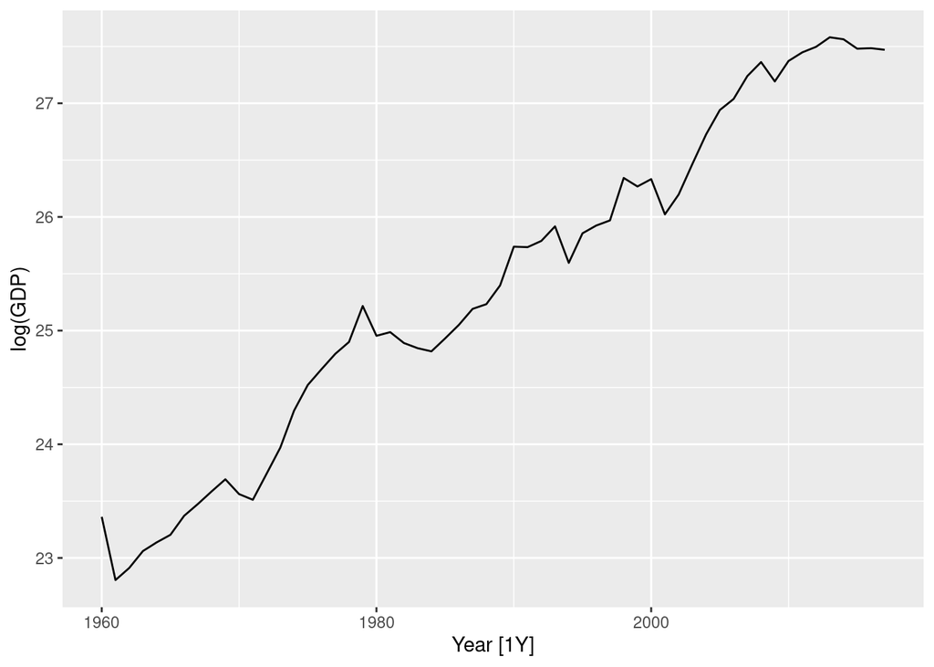

```r
turkey |> autoplot(log(GDP))
```

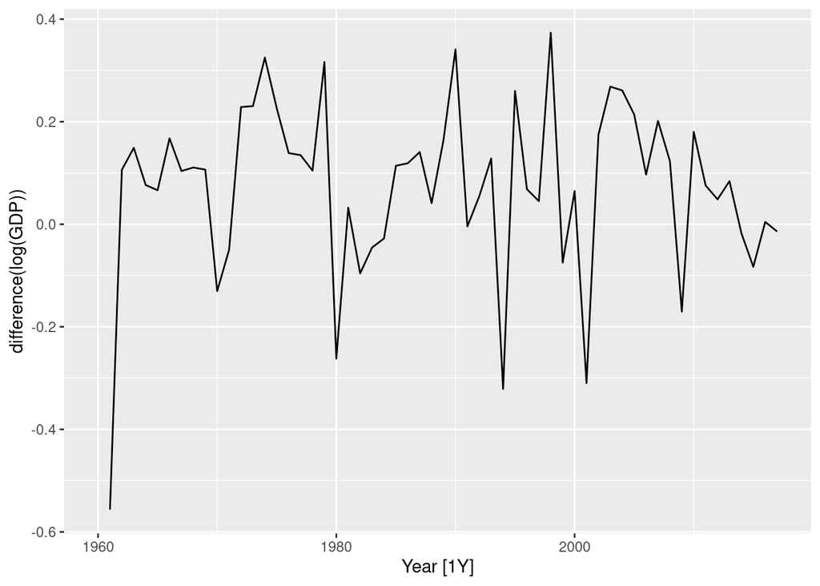

```r
turkey |> autoplot(log(GDP) |> difference())
```

```r
turkey |> features(GDP, guerrero)
```

| Country | lambda_guerrero |
| --- | --- |
| Turkey | 0.1572187 |

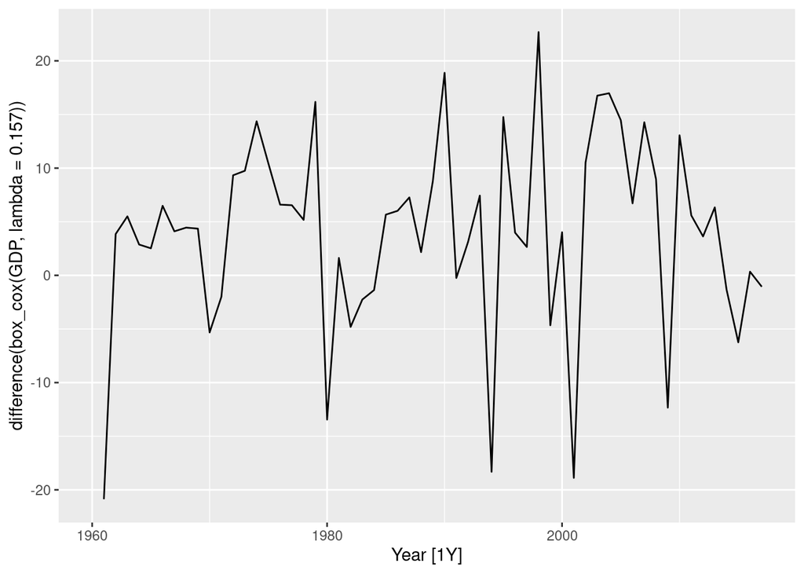

```r
turkey |> autoplot(box_cox(GDP, lambda=0.157) |> difference())
```

- Logs and differences make the data appear stationary.
- Using a Box-Cox transformation with $\lambda$ between 0 and 0.2 would also have worked well.
2. Accommodation takings in the state of Tasmania from `aus_accommodation`.

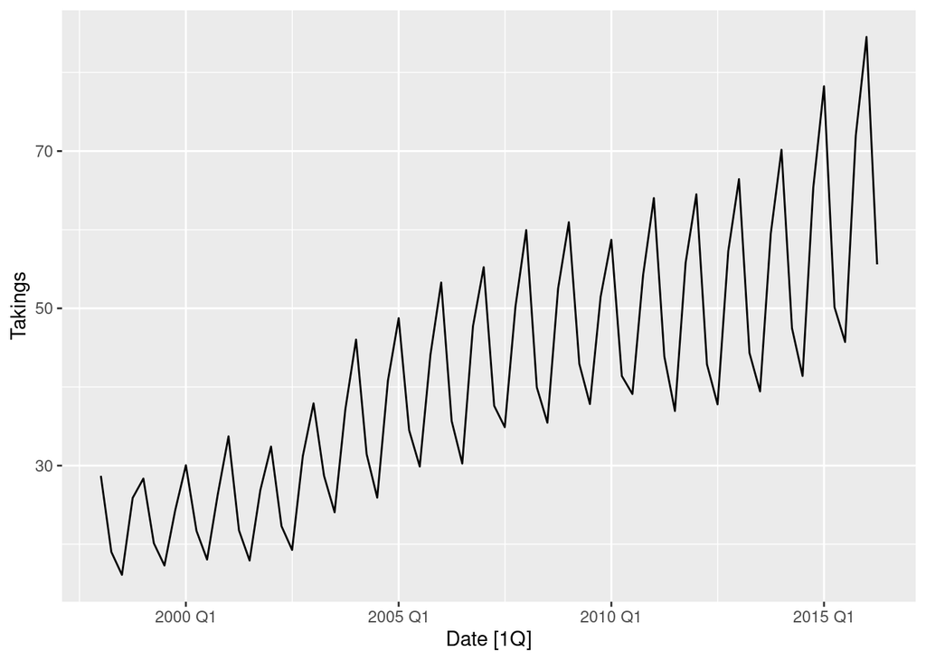

```r
tas <- aus_accommodation |> filter(State == "Tasmania")
tas |> autoplot(Takings)
```

[output not shown]

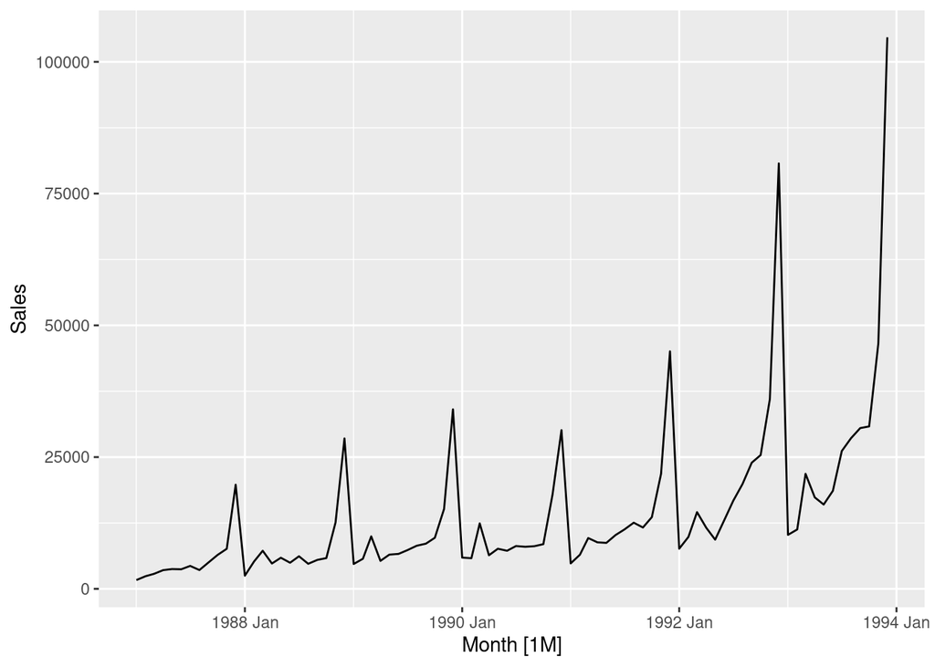

```r
souvenirs |> autoplot(Sales)
```

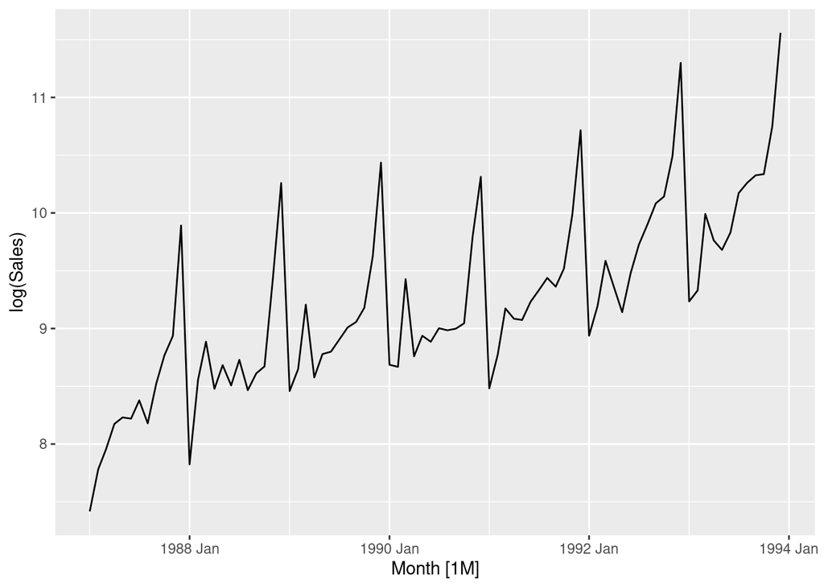

```r
souvenirs |> autoplot(log(Sales))
```

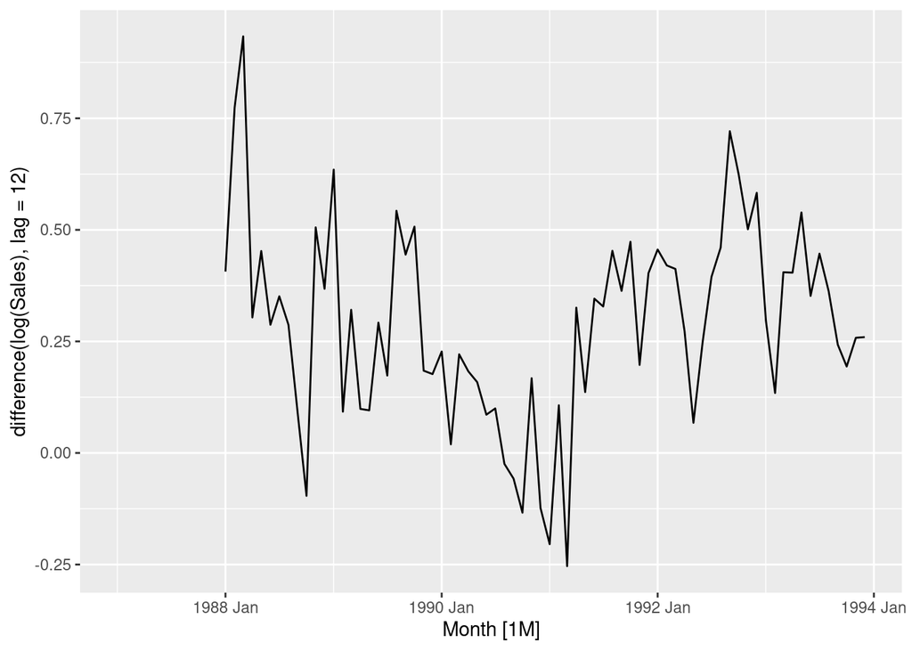

```r
souvenirs |> autoplot(log(Sales) |> difference(lag=12))
```

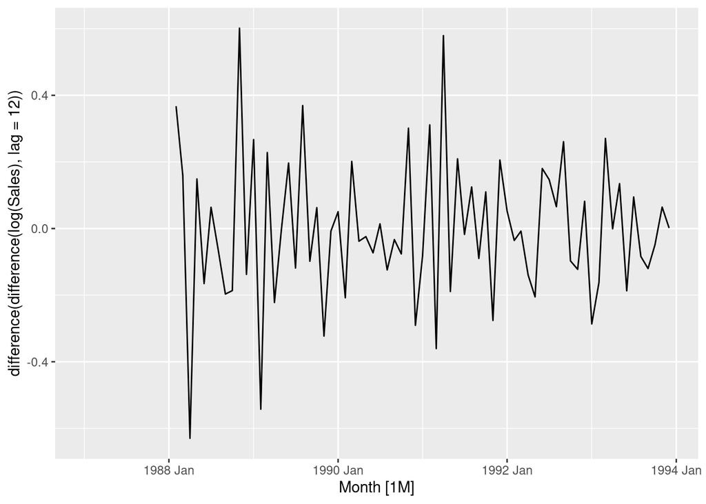

```r
souvenirs |> autoplot(log(Sales) |> difference(lag=12) |> difference())
```

```r
souvenirs |> features(Sales, guerrero)
```

| lambda_guerrero |
| --- |
| 0.002118221 |

- Logs followed by seasonal and first differences make the data appear stationary.
- The automatically selected Box-Cox $\lambda$ value is very close to zero, confirming the choice of using logs.

Let $y_t =$ log(Sales). Then $(1-B^{12})(1-B)y_t$ gives the differences used above.